Demand forecasting · time series analysis

DataSphere Analytics

# Sporting goods retail in France: 27 years of monthly demand

Stationarity, decomposition, drift, anomaly detection and forecast benchmarking, from seasonal naive to Chronos-2, on public INSEE data

Théophile L. Mouton

2026-11-18

> **Key findings**
> - **Growth has stalled.** The trend grew by 4.7 % a year between 2000 and 2019, but only 0.8 % a year between 2022 and 2025, in current euros, so likely a decline in volume once inflation is accounted for.
> - **Seasonality is drifting.** August now sits 36 % above trend (versus 30 % in 2010-2019), December has weakened, and the November trough has become shallower.
> - **Covid breaks naive pipelines.** Robust anomaly detection flags the lockdowns (April 2020: -78 % versus expected). Neutralising them cuts the ETS 12-month error from 7.9 % to 3.0 %.
> - **The simplest model wins on a flat market.** In a rolling backtest, the seasonal naive benchmark (2.4 % MAPE) beats ETS, ARIMA and Theta.
> - **A foundation model is the most robust and best calibrated.** Used zero-shot, without any training on this series, Chronos-2 reaches 3.4 % MAPE, barely degrades on uncleaned Covid data (3.6 %), and its 80 % intervals cover 81 % of outcomes.

## Why this analysis

Demand forecasting in retail starts with understanding the series: is it stationary, how strong and how stable is the seasonality, which observations are anomalies, and has the process drifted? Product-level sales are confidential, but INSEE publishes a monthly turnover index for **retail sale of sporting equipment in specialised stores** (NAF rev. 2 class 47.64). It covers January 1999 to August 2026, which makes it a good public testbed for the full workflow: stationarity tests, decomposition, anomaly detection, drift detection and honest forecast evaluation.

**How to read the index.** Each value is the turnover of one month (sales, in current euros) of all stores specialised in sporting goods in France, divided by the average monthly turnover of 2021 and multiplied by 100. A value of 150 means sales 50 % above an average month of 2021; a value of 50 means half. Because it is a ratio, it shows changes over time, not the size of the market in euros. The series is unadjusted: it keeps the seasonal pattern and calendar effects, which are what we want to model. All modelling is done on the log scale.

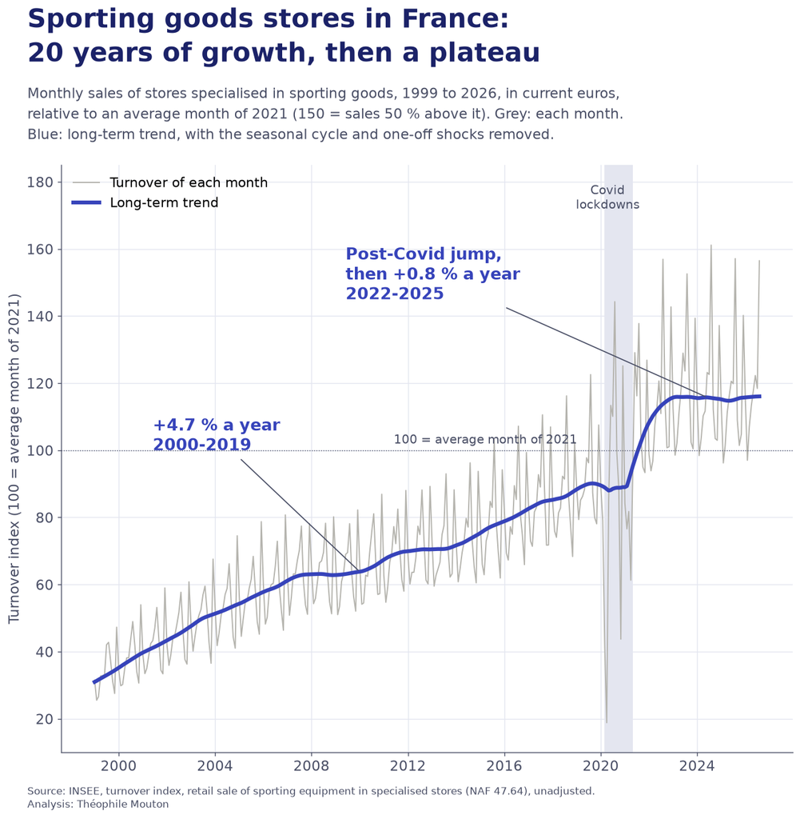

Figure 1: Monthly turnover of sporting goods stores in France and its long-term trend (robust STL). The within-year saw-tooth pattern is unpacked in Figure 4.

```python
fig, ax = poster("Sporting goods stores in France:", "20 years of growth, then a plateau",
                 "Monthly sales of stores specialised in sporting goods, 1999 to 2026, in current euros,\n"
                 "relative to an average month of 2021 (150 = sales 50 % above it). Grey: each month.\n"
                 "Blue: long-term trend, with the seasonal cycle and one-off shocks removed.")
ax.axvspan(pd.Timestamp("2020-03-01"), pd.Timestamp("2021-05-01"), color=GRID, lw=0)
ax.text(pd.Timestamp("2020-04-15"), 172, "Covid\nlockdowns", fontsize=11, color=INK2, ha="center")
ax.plot(df.index, df["brut"], color=GREY, lw=1.1, label="Turnover of each month")
ax.plot(tr.index, tr, color=SURF, lw=3.5, label="Long-term trend")
ax.axhline(100, color=INK2, lw=0.8, ls=":")
ax.text(pd.Timestamp("2011-06-01"), 102, "100 = average month of 2021", fontsize=11, color=INK2)
ax.annotate(f"+{pct(cagr_pre)} % a year\n2000-2019", xy=(pd.Timestamp("2010-01-01"), tr.loc["2010-01-01"]),
            xytext=(pd.Timestamp("2001-06-01"), 100), fontsize=15, color=SURF, weight="bold",
            arrowprops=dict(arrowstyle="-", color=INK2, lw=1))
ax.annotate(f"Post-Covid jump,\nthen +{pct(cagr_post)} % a year\n2022-2025",
            xy=(pd.Timestamp("2024-06-01"), tr.loc["2024-06-01"]),
            xytext=(pd.Timestamp("2009-06-01"), 145), fontsize=15, color=SURF, weight="bold",
            arrowprops=dict(arrowstyle="-", color=INK2, lw=1))
ax.set_ylim(10, 185)
ax.set_ylabel("Turnover index (100 = average month of 2021)", fontsize=13)
ax.tick_params(labelsize=13)
ax.xaxis.set_major_locator(mdates.YearLocator(4))
ax.xaxis.set_major_formatter(mdates.DateFormatter("%Y"))
ax.legend(loc="upper left", fontsize=12)
plt.show()
```

## 1. Stationarity

The augmented Dickey-Fuller test (null hypothesis: unit root) and the KPSS test (null hypothesis: stationarity) are complementary, so they are read together.

```python
stat.style.format("{:.3f}")
```

Table 1: Unit root (ADF) and stationarity (KPSS) tests on the log series. KPSS p-values are truncated at 0.01 and 0.10.

|  | ADF p-value | KPSS p-value |
| --- | --- | --- |
| log level | 0.395 | 0.010 |
| first difference | 0.000 | 0.100 |
| seasonal difference (12) | 0.000 | 0.100 |
| both differences | 0.000 | 0.100 |

The log level is non-stationary (ADF does not reject a unit root, KPSS rejects stationarity). After first or seasonal differencing both tests agree on stationarity. This points to a stochastic trend plus a strong annual cycle: models need either differencing (ARIMA) or an explicit trend and seasonal state (ETS).

## 2. Decomposition

A robust STL decomposition (period 12) separates trend, seasonality and remainder. The robust weights stop the Covid months from distorting the trend and seasonal estimates.

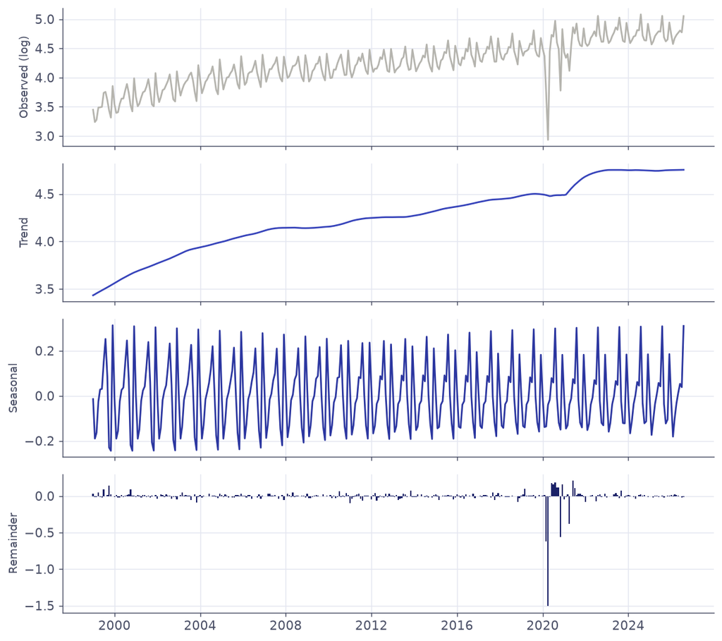

Figure 2: Robust STL decomposition of the log turnover index.

```python
fig, axes = plt.subplots(4, 1, figsize=(9, 8), sharex=True)
for ax, col, lab, c in zip(axes, ["obs", "trend", "seasonal", "resid"],
                           ["Observed (log)", "Trend", "Seasonal", "Remainder"],
                           [GREY, SURF, MID, DEEP]):
    if col == "resid":
        ax.bar(dec.index, dec[col], width=25, color=c)
    else:
        ax.plot(dec.index, dec[col], color=c, lw=1.5)
    ax.set_ylabel(lab, fontsize=10)
plt.tight_layout()
plt.show()
```

## 3. Anomaly detection

Anomalies are flagged on the STL remainder using a robust z-score (median and MAD rather than mean and standard deviation), with a threshold of |z| > 3.5. A robust scale matters here: a few extreme Covid months would otherwise inflate the standard deviation and hide everything else.

```python
out = anom[["z", "vs_expected_pct"]].copy()
out.index = out.index.strftime("%Y-%m")
out.columns = ["Robust z-score", "Deviation from expected (%)"]
out.style.format("{:.1f}")
```

Table 2: Months flagged as anomalous, with the deviation from the trend plus seasonal expectation.

| ds | Robust z-score | Deviation from expected (%) |
| --- | --- | --- |
| 1999-07 | 5.1 | 9.9 |
| 1999-10 | 7.9 | 15.5 |
| 2000-10 | 4.9 | 9.5 |
| 2003-11 | -5.1 | -8.7 |
| 2010-07 | 3.5 | 6.7 |
| 2011-01 | -5.7 | -9.7 |
| 2013-11 | 4.0 | 7.6 |
| 2018-11 | -4.4 | -7.5 |
| 2019-03 | 5.2 | 10.1 |
| 2020-03 | -34.3 | -46.1 |
| 2020-04 | -83.6 | -77.9 |
| 2020-06 | 9.5 | 18.9 |
| 2020-07 | 8.7 | 17.3 |
| 2020-08 | 10.2 | 20.5 |
| 2020-09 | 6.5 | 12.7 |
| 2020-10 | 6.4 | 12.5 |
| 2020-11 | -31.0 | -42.8 |
| 2020-12 | 8.7 | 17.2 |
| 2021-04 | -21.1 | -31.6 |
| 2021-06 | 11.5 | 23.3 |
| 2021-07 | 5.7 | 11.0 |
| 2022-01 | -4.6 | -7.8 |
| 2022-07 | -4.1 | -6.9 |
| 2023-09 | 4.1 | 7.9 |

The Covid lockdowns dominate (March-April 2020, November 2020, April 2021), followed by catch-up months that are just as anomalous in the other direction. Isolated pre-Covid flags are much smaller (mostly under 10 %) and plausibly linked to weather, calendar or promotional effects.

## 4. Drift

### Trend

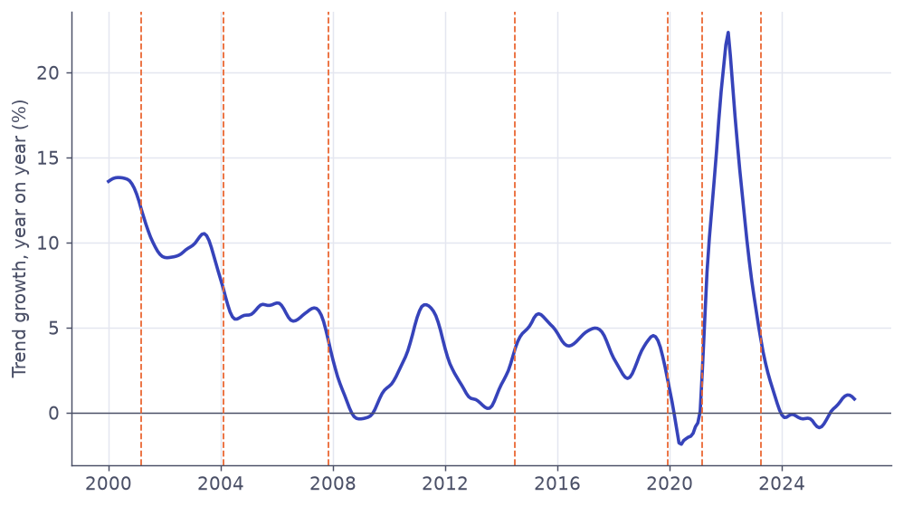

Figure 3: Year-on-year growth of the STL trend. Dashed lines mark change points detected with PELT.

```python
fig, ax = plt.subplots()
gg = (np.exp(g) - 1) * 100
ax.plot(gg.index, gg, color=SURF, lw=2)
ax.axhline(0, color=INK2, lw=0.8)
for b in breaks:
    ax.axvline(b, color=ORANGE, ls="--", lw=1)
ax.set_ylabel("Trend growth, year on year (%)")
plt.show()
```

Change-point detection (PELT, RBF cost) on the year-on-year trend growth finds breaks at 2001-03, 2004-02, 2007-11, 2014-07, 2019-12, 2021-03, 2023-04. The last regime, since 2023, is a plateau: 0.8 % a year against 4.7 % on average before Covid.

### Seasonality

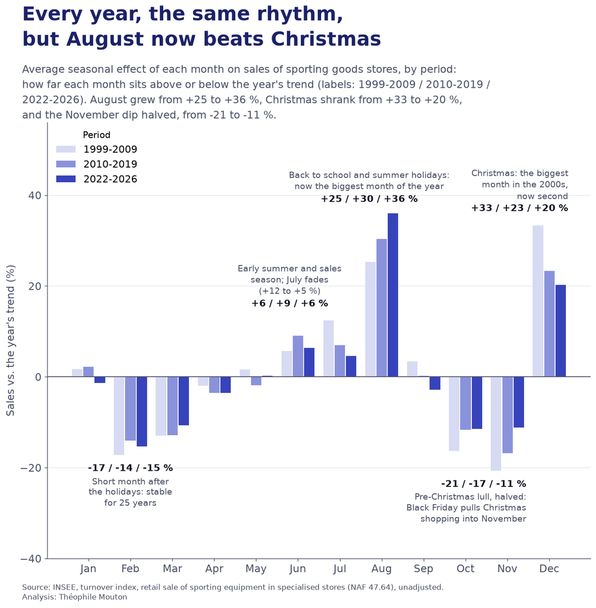

Figure 4: Average seasonal effect of each month, by period, from the robust STL decomposition.

```python
months = ["Jan", "Feb", "Mar", "Apr", "May", "Jun", "Jul", "Aug", "Sep", "Oct", "Nov", "Dec"]
periods = ["1999-2009", "2010-2019", "2022-2026"]
a8, d12, n11 = prof.loc[8, periods].values, prof.loc[12, periods].values, prof.loc[11, periods].values
fig, ax = poster("Every year, the same rhythm,", "but August now beats Christmas",
                 "Average seasonal effect of each month on sales of sporting goods stores, by period:\n"
                 "how far each month sits above or below the year's trend (labels: 1999-2009 / 2010-2019 /\n"
                 f"2022-2026). August grew from {a8[0]:+.0f} to {a8[2]:+.0f} %, Christmas shrank from {d12[0]:+.0f} to {d12[2]:+.0f} %,\n"
                 f"and the November dip halved, from {n11[0]:+.0f} to {n11[2]:+.0f} %.")
x = np.arange(12)
w = 0.27
for i, (col, c) in enumerate(zip(periods, [FOAM, LIGHT, SURF])):
    ax.bar(x + (i - 1) * w, prof[col].values, w * 0.92, color=c, label=col)
ax.axhline(0, color=INK2, lw=1)

def lab(m, txt, up=True, y=None, ha="center", dx=0):
    vals = prof.loc[m, periods].values
    if y is None:
        y = (vals.max() + 2) if up else (vals.min() - 2)
    seq = " / ".join(f"{v:+.0f}" for v in vals)
    ax.text(m - 1 + dx, y, f"{seq} %", ha=ha, va="bottom" if up else "top", fontsize=11.5,
            color="#101322", weight="bold")
    off = 2.6
    ax.text(m - 1 + dx, y + off if up else y - off, txt, ha=ha, va="bottom" if up else "top",
            fontsize=10.5, color=INK2, linespacing=1.3)

j = prof.loc[7, periods].values
lab(8, "Back to school and summer holidays:\nnow the biggest month of the year", dx=-0.3)
lab(12, "Christmas: the biggest\nmonth in the 2000s,\nnow second", ha="right", dx=0.45, y=36)
lab(6, f"Early summer and sales\nseason; July fades\n({j[0]:+.0f} to {j[2]:+.0f} %)", y=15, dx=-0.2)
lab(2, "Short month after\nthe holidays: stable\nfor 25 years", up=False)
lab(11, "Pre-Christmas lull, halved:\nBlack Friday pulls Christmas\nshopping into November",
    up=False, ha="right", dx=0.45)
ax.set_xticks(x, months)
ax.set_ylim(-40, 56)
ax.set_ylabel("Sales vs. the year's trend (%)", fontsize=13)
ax.tick_params(labelsize=13)
ax.grid(axis="x", visible=False)
ax.legend(loc="upper left", fontsize=12, title="Period", title_fontsize=11)
plt.show()
```

```python
t = prof.copy()
t.index = months
t.T.style.format("{:+.0f}")
```

Table 3: Seasonal profile by period (deviation from trend, %).

|  | Jan | Feb | Mar | Apr | May | Jun | Jul | Aug | Sep | Oct | Nov | Dec |
| --- | --- | --- | --- | --- | --- | --- | --- | --- | --- | --- | --- | --- |
| 1999-2009 | +2 | -17 | -13 | -2 | +2 | +6 | +12 | +25 | +3 | -16 | -21 | +33 |
| 2010-2019 | +2 | -14 | -13 | -4 | -2 | +9 | +7 | +30 | +0 | -12 | -17 | +23 |
| 2022-2026 | -1 | -15 | -11 | -4 | +0 | +6 | +5 | +36 | -3 | -11 | -11 | +20 |

**What drives the within-year pattern.** The seasonal component is measured, the causes below are the usual explanations for sporting goods retail, not tested here:

- **August (+36 %)**: back to school and the start of the club season (school sports kits, sports club registrations in September), plus summer holidays (outdoor, swimming, cycling, camping).
- **December (+20 %)**: Christmas gifts.
- **June-July (+5 to +6 %)**: start of summer and summer sales (soldes) from late June.
- **February (-15 %)**: shortest month and post-holiday spending lull; winter sales in January partly pull purchases forward.
- **October-November (-11 %)**: quiet period between back-to-school and Christmas, now partly filled by Black Friday.
- **Calendar effects**: because the series is unadjusted, the number of days and of Saturdays in each month also moves the monthly figures.

The seasonal pattern is not fixed. Back-to-school and summer (August) has grown, while December has lost weight, and November has become less of a trough. Black Friday shifting spend from December to November is a plausible explanation, though it is not tested here. For a forecasting pipeline this means seasonal factors estimated on long histories will be biased, and models that let seasonality evolve, or that weight recent years, should be preferred.

## 5. Forecast benchmarking

Four statistical models from `statsforecast` and one time series foundation model (Chronos-2, zero-shot) are compared in a rolling-origin backtest: 12-month horizon, three origins (2023-08, 2024-08, 2025-08), each refit on all data available at the origin. Each model is run on the raw series and on a version where March 2020 to May 2021 is replaced by the STL trend plus seasonal estimate.

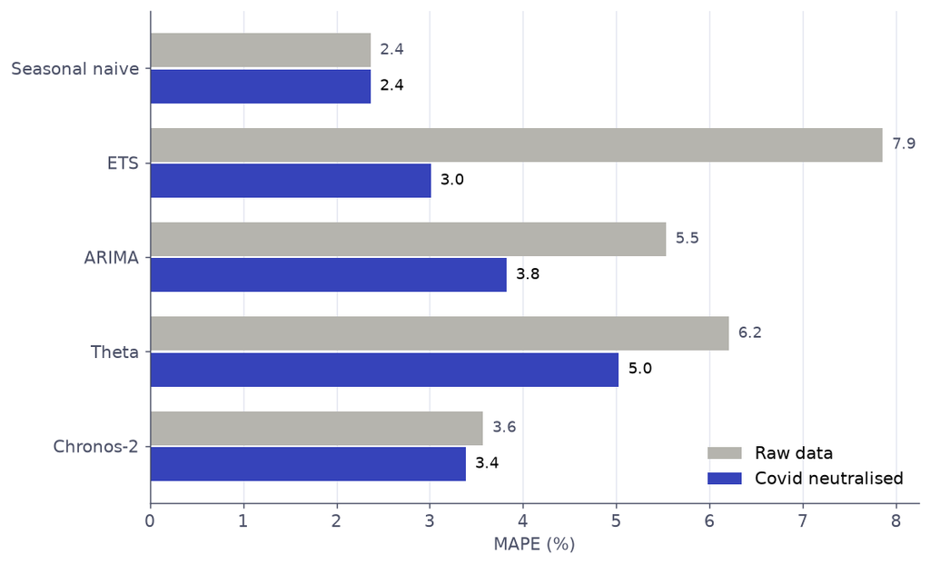

Figure 5: 12-month-ahead MAPE by model, raw versus Covid-neutralised history.

```python
order = ["Seasonal naive", "ETS", "ARIMA", "Theta", "Chronos-2"]
yy = np.arange(len(order))[::-1]
h = 0.38
fig, ax = plt.subplots(figsize=(9, 5.8))
ax.barh(yy + h / 2, btr.loc[order, "MAPE (%)"], h * 0.95, color=GREY, label="Raw data")
ax.barh(yy - h / 2, btc.loc[order, "MAPE (%)"], h * 0.95, color=SURF, label="Covid neutralised")
for yi, v in zip(yy, btr.loc[order, "MAPE (%)"]):
    ax.text(v + 0.1, yi + h / 2, f"{v:.1f}", va="center", fontsize=10, color=INK2)
for yi, v in zip(yy, btc.loc[order, "MAPE (%)"]):
    ax.text(v + 0.1, yi - h / 2, f"{v:.1f}", va="center", fontsize=10)
ax.set_yticks(yy, order)
ax.set_xlabel("MAPE (%)")
ax.grid(axis="y", visible=False)
ax.legend(loc="lower right")
plt.show()
```

```python
bt.style.format({"MAPE (%)": "{:.2f}", "Bias (%)": "{:+.2f}", "80% interval coverage (%)": "{:.0f}"}).hide(axis="index")
```

Table 4: Backtest metrics. Bias is the mean signed percentage error (positive means over-forecasting).

| Data | Model | MAPE (%) | Bias (%) | 80% interval coverage (%) |
| --- | --- | --- | --- | --- |
| Raw data | Seasonal naive | 2.37 | +0.13 | 100 |
| Raw data | ETS | 7.86 | +6.26 | 100 |
| Raw data | ARIMA | 5.53 | +2.21 | 100 |
| Raw data | Theta | 6.21 | +2.69 | 100 |
| Raw data | Chronos-2 | 3.57 | +2.56 | 81 |
| Covid neutralised | Seasonal naive | 2.37 | +0.13 | 100 |
| Covid neutralised | ETS | 3.01 | +2.15 | 89 |
| Covid neutralised | ARIMA | 3.82 | +2.73 | 86 |
| Covid neutralised | Theta | 5.03 | +2.09 | 72 |
| Covid neutralised | Chronos-2 | 3.39 | +2.30 | 81 |

Three lessons:

1. **Cleaning the Covid period matters more than the choice of model.** On raw data, ETS over-forecasts by about 6 %, most likely because it reads the 2020-2022 rebound as trend. Neutralising those months cuts its error by a factor of 2.6.
2. **On a flat market, seasonal naive is hard to beat.** Once growth stops and seasonality is stable year to year, repeating last year is a strong forecast. Any production model should be benchmarked against it.
3. **Check calibration, not just accuracy.** Theta’s 80 % intervals cover only 72 % of outcomes, so it is overconfident. Stock decisions depend on the interval, not the point forecast.

### A time series foundation model, zero-shot

[Chronos-2](https://huggingface.co/amazon/chronos-2) is a pretrained forecasting model: it receives the history up to each origin and returns quantile forecasts, with no fitting on this series. It runs on a laptop CPU. The forecasts are precomputed by `scripts/chronos_backtest.py` on exactly the same origins and horizon as the statistical models.

```python
from chronos import Chronos2Pipeline

pipe = Chronos2Pipeline.from_pretrained("amazon/chronos-2", device_map="cpu")
fc = pipe.predict_df(context,                       # history up to the origin
                     prediction_length=12,
                     quantile_levels=[0.025, 0.1, 0.5, 0.9, 0.975],
                     id_column="unique_id", timestamp_column="ds", target="y")
```

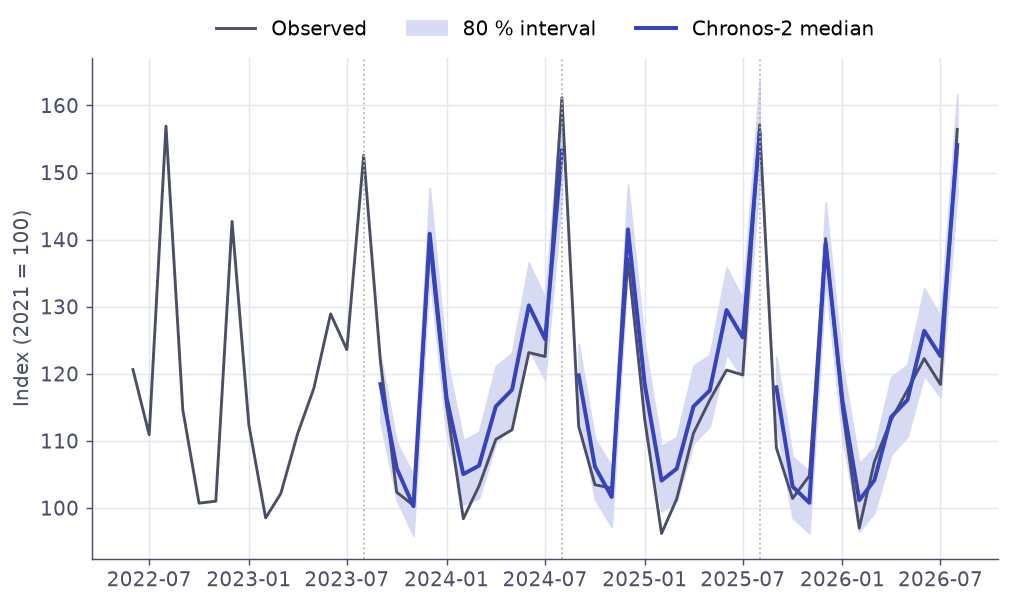

Figure 6: Chronos-2 zero-shot forecasts (median and 80 % interval) at the three backtest origins, Covid-neutralised history, against observed values.

```python
gcv = ch[ch["data"] == "Covid neutralised"]
obs = df.loc["2022-06-01":, "brut"]
fig, ax = plt.subplots()
ax.plot(obs.index, obs, color=INK2, lw=1.6, label="Observed")
for i, (c, gc) in enumerate(gcv.groupby("cutoff")):
    ax.fill_between(gc["ds"], gc["q0.1"], gc["q0.9"], color=FOAM, label="80 % interval" if i == 0 else None)
    ax.plot(gc["ds"], gc["q0.5"], color=SURF, lw=2.2, label="Chronos-2 median" if i == 0 else None)
    ax.axvline(c, color=GREY, ls=":", lw=1)
ax.set_ylabel("Index (2021 = 100)")
ax.legend(loc="lower center", bbox_to_anchor=(0.5, 1.0), ncol=3)
plt.show()
```

What the foundation model brings:

- **Robustness without manual cleaning.** On raw data its error is 3.6 %, against 7.9 % for ETS. The statistical models need the Covid months to be neutralised by hand; Chronos-2 barely needs it.
- **Calibrated uncertainty.** Its 80 % intervals cover 81 % of outcomes, close to nominal, whereas seasonal naive intervals are so wide they cover everything and Theta’s are too narrow.
- **Not a free win on point accuracy.** On this flat aggregate series, repeating last year (2.4 %) still beats it. The case for foundation models is strongest at scale, on many short, noisy or new-product series, where hand-tuning each model is impossible. That is also where fine-tuning on internal history pays off.

One caveat: public pretraining corpora may include INSEE series, so a zero-shot result on public data can be optimistic.

## 6. Five-year outlook

A 12-month forecast is what replenishment needs, but strategy needs the longer view. For five years ahead, repeating last year is no longer sensible: the model has to carry the trend. ETS with a damped trend, fitted automatically on the Covid-neutralised log series, is the second-best model in the backtest and the natural choice here: it lets the recent plateau continue unless the data say otherwise, and its prediction intervals widen with the horizon.

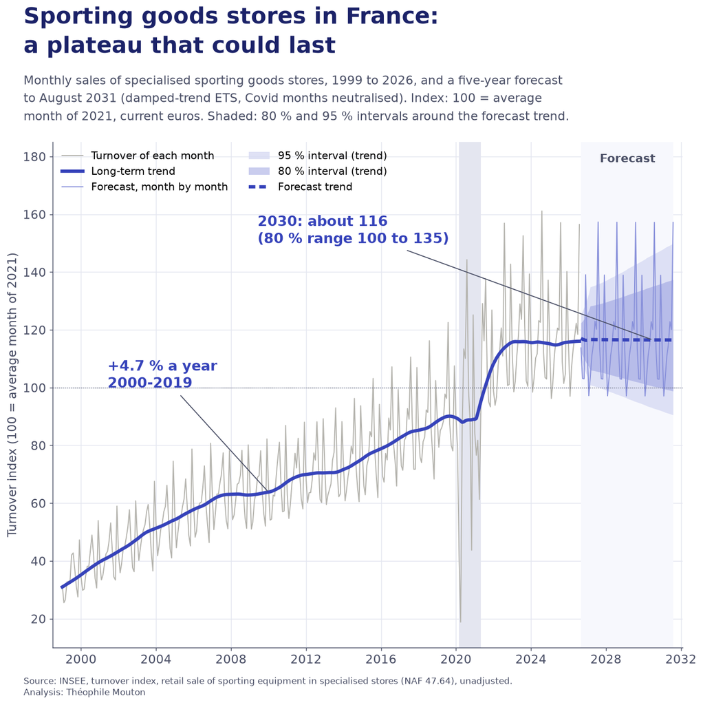

Figure 7: Five-year outlook: monthly turnover index with its long-term trend, extended by a damped-trend ETS forecast. Shaded bands are the 80 % and 95 % prediction intervals smoothed around the forecast trend (12-month centred average). The forecast extends the current regime, without covariates: it is a scenario, not a prediction of the drivers.

```python
fig, ax = poster("Sporting goods stores in France:", "a plateau that could last",
                 f"Monthly sales of specialised sporting goods stores, 1999 to {last.year}, and a five-year forecast\n"
                 f"to {fc_lt.index[-1].strftime('%B %Y')} (damped-trend ETS, Covid months neutralised). Index: 100 = average\n"
                 "month of 2021, current euros. Shaded: 80 % and 95 % intervals around the forecast trend.")
ax.axvspan(pd.Timestamp("2020-03-01"), pd.Timestamp("2021-05-01"), color=GRID, lw=0)
ax.axvspan(fc_lt.index[0], fc_lt.index[-1], color="#f7f8fd", lw=0)
ax.text(fc_lt.index[0] + pd.DateOffset(months=30), 178, "Forecast", fontsize=12, color=INK2, ha="center", weight="bold")
ax.plot(df.index, df["brut"], color=GREY, lw=1.1, label="Turnover of each month")
ax.plot(tr.index, tr, color=SURF, lw=3.5, label="Long-term trend")
sm = deseas
ax.plot(fc_lt.index, fc_lt["AutoETS"], color=LIGHT, lw=1.1, label="Forecast, month by month")
ax.fill_between(fc_lt.index, sm("AutoETS-lo-95"), sm("AutoETS-hi-95"), color=FOAM, alpha=0.8, lw=0, label="95 % interval (trend)")
ax.fill_between(fc_lt.index, sm("AutoETS-lo-80"), sm("AutoETS-hi-80"), color=LIGHT, alpha=0.45, lw=0, label="80 % interval (trend)")
ax.plot(lt_smooth.index, lt_smooth, color=SURF, lw=3.5, ls=(0, (2, 1.2)), label="Forecast trend")
ax.axhline(100, color=INK2, lw=0.8, ls=":")
ax.annotate(f"+{pct(cagr_pre)} % a year\n2000-2019", xy=(pd.Timestamp("2010-01-01"), tr.loc["2010-01-01"]),
            xytext=(pd.Timestamp("2001-06-01"), 100), fontsize=15, color=SURF, weight="bold",
            arrowprops=dict(arrowstyle="-", color=INK2, lw=1))
ax.annotate(f"{last_full}: about {lt_mid:.0f}\n(80 % range {lt_lo:.0f} to {lt_hi:.0f})",
            xy=(pd.Timestamp(f"{last_full}-07-01"), lt_smooth.loc[f"{last_full}-07-01"]),
            xytext=(pd.Timestamp("2009-06-01"), 150), fontsize=15, color=SURF, weight="bold",
            arrowprops=dict(arrowstyle="-", color=INK2, lw=1))
ax.set_ylim(10, 185)
ax.set_xlim(df.index[0] - pd.DateOffset(months=6), fc_lt.index[-1] + pd.DateOffset(months=6))
ax.set_ylabel("Turnover index (100 = average month of 2021)", fontsize=13)
ax.tick_params(labelsize=13)
ax.xaxis.set_major_locator(mdates.YearLocator(4))
ax.xaxis.set_major_formatter(mdates.DateFormatter("%Y"))
ax.legend(loc="upper left", fontsize=11, ncol=2)
Path("figures").mkdir(exist_ok=True)
fig.savefig("figures/linkedin_outlook.png", dpi=150)
plt.show()
```

The 80 % interval is wide, and that is the point: after a regime change like Covid, five-year forecasts of an aggregate series carry real uncertainty, and a single number would hide it. For the next 12 months, the seasonal naive forecast from section 5 remains the more accurate choice: the December 2026 peak is expected at 140 (80 % interval 128 to 154).

## Limitations and next steps

- **Aggregate, value-based series.** This is a national turnover index, not unit sales by product and store. Inflation is mixed with volume, and the hierarchical, intermittent and promotion-driven structure of real assortment data is absent.
- **Short backtest.** Three yearly origins give 36 forecast points. Results are indicative, not a definitive model ranking.
- **Covid neutralisation uses the full-sample STL fit.** The imputed months lie before all backtest origins, so leakage is minimal, but a strictly causal version would refit STL at each origin.
- **Next steps:** exogenous drivers (weather, calendar, Black Friday and Olympics dummies) as Chronos-2 covariates, a deflated volume series, other foundation models (TimesFM, Moirai), and an ensemble of seasonal naive and Chronos-2.

## Reproducibility

Data: INSEE, *Indice de chiffre d’affaires - Commerce de détail d’articles de sport en magasin spécialisé* (NAF rév. 2, 47.64), series 010770520 (raw) and 010770580 (seasonally and calendar adjusted), retrieved from the INSEE BDM SDMX API. `scripts/fetch_insee.py` refreshes the data, `scripts/chronos_backtest.py` recomputes the Chronos-2 forecasts (separate environment with PyTorch, see `requirements-chronos.txt`), and `quarto render report.qmd` rebuilds this page.